# Exploratory Data Analysis of WMATA Transit System

Tomato Smoothie🍅

2025-03-19

## 📊 Introduction

This document presents a comprehensive exploratory data analysis (EDA) of the Washington Metropolitan Area Transit Authority (WMATA) system. The analysis examines multiple aspects of WMATA’s ridership patterns including:

- Daily and monthly ridership trends
- Station-level usage patterns across the Metrorail system
- Peak vs. off-peak travel behavior
- Fare technology adoption (tap vs. non-tap entries)
- Travel patterns by time period

The insights derived from this analysis can help WMATA planners optimize service schedules, allocate resources efficiently, and improve the passenger experience across the network.

## 🔧 Data Preparation

### 📚 Load Required Libraries

```r
# Data manipulation libraries
library(dplyr)      # For data transformation
library(tidyr)      # For data cleaning
library(readr)      # For reading CSV files

# Date and time handling
library(lubridate)  # For date manipulation

# Visualization libraries
library(ggplot2)    # For creating graphs
library(gridExtra)  # For arranging multiple plots
library(reshape2)   # For reshaping data
library(forcats)    # For factor manipulation
library(stringr)    # For string manipulation
```

### 📥 Import Data Sources

```r
# Import main ridership datasets
total_entries_exits <- read_csv("Total_Entries_and_Exits_Processed.csv")
entries_over_time <- read_csv("Entries_Over_Time_Processed.csv")
entries_by_tap <- read_csv("Entries_by_Tap_and_noTap_Processed.csv")

# Import aggregated boardings data
boardings_by_day <- read_csv("Boardings_by_Day_of_Week_Processed.csv")
boardings_by_month <- read_csv("Cleaned_Boardings_Data.csv")
boardings_weekends <- read_csv("Boardings_Weekends_Processed.csv")

# Import time-based and station-based data
boardings_time_period <- read_csv("Boardings_by_Time_Period_Processed.csv")
entries_by_year <- read_csv("Entries_by_Year_Processed.csv")
boardings_by_route <- read_csv("Boardings_by_Route_Table_Processed.csv")
```

### 🧹 Data Cleaning and Preprocessing

```r
# ---- Handle date and day columns ----
# Identify appropriate column names based on what's available in the data
date_col_name <- if("Date" %in% names(total_entries_exits)) "Date" else "Column_0"
day_col_name <- if("Day" %in% names(total_entries_exits)) "Day" else "Column_0"

# Extract and parse date information from text columns if needed
if("Column_0" %in% names(total_entries_exits) && !("Date" %in% names(total_entries_exits))) {
  # Check if Column_0 contains date strings (e.g., "Tuesday, March 11, 2025")
  sample_dates <- head(total_entries_exits$Column_0)
  date_pattern <- "\\w+,\\s+\\w+\\s+\\d+,\\s+\\d{4}"

  if(any(grepl(date_pattern, sample_dates))) {
    # Parse dates by removing the day of week prefix
    total_entries_exits$Date <- mdy(gsub("^\\w+,\\s+", "", total_entries_exits$Column_0))

    # Extract day of week from the full string
    total_entries_exits$Day <- sub(",.*$", "", total_entries_exits$Column_0)
  }
}

# ---- Clean numeric fields ----
# Convert string numbers with commas to numeric values
if(is.character(total_entries_exits$Entries)) {
  total_entries_exits$Entries <- as.numeric(stringr::str_replace_all(total_entries_exits$Entries, ",", ""))
}
if(is.character(total_entries_exits$Exits)) {
  total_entries_exits$Exits <- as.numeric(stringr::str_replace_all(total_entries_exits$Exits, ",", ""))
}

# Verify data quality after conversion
if(any(is.na(total_entries_exits$Entries)) || any(is.na(total_entries_exits$Exits))) {
  warning("NAs introduced during number conversion - check data format")
}

# ---- Standardize categorical variables ----
# Ensure days of week are properly ordered
day_levels <- c("Sunday", "Monday", "Tuesday", "Wednesday", "Thursday", "Friday", "Saturday")
if("Day" %in% names(total_entries_exits)) {
  total_entries_exits$Day <- factor(total_entries_exits$Day, levels = day_levels)
}

# ---- Standardize column names across datasets ----
# Process boardings_by_day dataframe
if("Day of Week" %in% names(boardings_by_day)) {
  boardings_by_day <- boardings_by_day %>% rename(Day = `Day of Week`)
}

# Identify and standardize value column in boardings_by_day
boardings_column_names <- names(boardings_by_day)
if(length(boardings_column_names) >= 2) {
  if(!"Boardings" %in% boardings_column_names) {
    boardings_value_col <- boardings_column_names[2]  # Assuming the value column is the second one
    boardings_by_day <- boardings_by_day %>% rename(Boardings = all_of(boardings_value_col))
  }
} else {
  warning("boardings_by_day doesn't have enough columns")
}

# Process station names in entries_by_tap
if("Station Name" %in% names(entries_by_tap)) {
  entries_by_tap <- entries_by_tap %>% rename(Station = `Station Name`)
}

# Create proper month ordering for time-based analysis
if("Month" %in% names(boardings_by_month)) {
  month_levels <- month.name  # Built-in R vector with month names
  boardings_by_month$Month <- factor(boardings_by_month$Month, levels = month_levels)
}
```

## 🔍 Exploratory Data Analysis

### 📋 Data Structure Overview

```r
# Display structure of main datasets to understand their composition
str(total_entries_exits)
```

```
## spc_tbl_ [4,819 × 5] (S3: spec_tbl_df/tbl_df/tbl/data.frame)
##  $ Column_0: chr [1:4819] "Tuesday, March 11, 2025" "Monday, March 10, 2025" "Sunday, March 9, 2025" "Saturday, March 8, 2025" ...
##  $ Entries : num [1:4819] 532830 448775 204056 270587 443326 ...
##  $ Exits   : num [1:4819] 531224 447657 204009 270463 443074 ...
##  $ Date    : Date[1:4819], format: "2025-03-11" "2025-03-10" ...
##  $ Day     : Factor w/ 7 levels "Sunday","Monday",..: 3 2 1 7 6 5 4 3 2 1 ...
##  - attr(*, "spec")=
##   .. cols(
##   ..   Column_0 = col_character(),
##   ..   Entries = col_double(),
##   ..   Exits = col_double()
##   .. )
##  - attr(*, "problems")=<externalptr>
```

```r
str(boardings_by_day)
```

```
## spc_tbl_ [7 × 2] (S3: spec_tbl_df/tbl_df/tbl/data.frame)
##  $ Day      : chr [1:7] "Sun" "Mon" "Tue" "Wed" ...
##  $ Boardings: num [1:7] 193391 319570 402263 404201 395828 ...
##  - attr(*, "spec")=
##   .. cols(
##   ..   `Day of Week` = col_character(),
##   ..   Column_1 = col_double()
##   .. )
##  - attr(*, "problems")=<externalptr>
```

### 📊 Summary Statistics

```r
# Generate summary statistics for key datasets
summary(total_entries_exits)
```

```
##    Column_0            Entries            Exits             Date
##  Length:4819        Min.   :    -25   Min.   :    43   Min.   :2012-01-01
##  Class :character   1st Qu.: 191864   1st Qu.:191116   1st Qu.:2015-04-19
##  Mode  :character   Median : 373277   Median :367380   Median :2018-08-06
##                     Mean   : 408941   Mean   :406412   Mean   :2018-08-06
##                     3rd Qu.: 650809   3rd Qu.:649624   3rd Qu.:2021-11-22
##                     Max.   :1005215   Max.   :960502   Max.   :2025-03-11
##
##         Day
##  Sunday   :689
##  Monday   :689
##  Tuesday  :689
##  Wednesday:688
##  Thursday :688
##  Friday   :688
##  Saturday :688
```

```r
summary(boardings_by_day)
```

```
##      Day              Boardings
##  Length:7           Min.   :193391
##  Class :character   1st Qu.:288395
##  Mode  :character   Median :345356
##                     Mean   :331118
##                     3rd Qu.:399046
##                     Max.   :404201
```

```r
summary(entries_by_year)
```

```
##    Column_0              2012             2013             2014
##  Length:2           Min.   :     0   Min.   :     0   Min.   :     0
##  Class :character   1st Qu.:175550   1st Qu.:172487   1st Qu.:169091
##  Mode  :character   Median :351101   Median :344974   Median :338182
##                     Mean   :351101   Mean   :344974   Mean   :338182
##                     3rd Qu.:526651   3rd Qu.:517462   3rd Qu.:507274
##                     Max.   :702201   Max.   :689949   Max.   :676365
##       2015             2016             2017             2018
##  Min.   :     0   Min.   :     0   Min.   :     0   Min.   :     0
##  1st Qu.:164266   1st Qu.:150615   1st Qu.:149157   1st Qu.:147107
##  Median :328531   Median :301230   Median :298314   Median :294214
##  Mean   :328531   Mean   :301230   Mean   :298314   Mean   :294214
##  3rd Qu.:492796   3rd Qu.:451844   3rd Qu.:447472   3rd Qu.:441322
##  Max.   :657062   Max.   :602459   Max.   :596629   Max.   :588429
##       2019             2020             2021             2022
##  Min.   :     0   Min.   :     0   Min.   :     0   Min.   :     0
##  1st Qu.:152246   1st Qu.: 43054   1st Qu.: 33451   1st Qu.: 56150
##  Median :304492   Median : 86108   Median : 66901   Median :112299
##  Mean   :304492   Mean   : 86108   Mean   : 66901   Mean   :112299
##  3rd Qu.:456738   3rd Qu.:129163   3rd Qu.:100352   3rd Qu.:168449
##  Max.   :608984   Max.   :172217   Max.   :133803   Max.   :224599
##       2023             2024             2025
##  Min.   : 40919   Min.   : 18466   Min.   : 16647
##  1st Qu.:109282   1st Qu.:107878   1st Qu.:107104
##  Median :177646   Median :197291   Median :197562
##  Mean   :177646   Mean   :197291   Mean   :197562
##  3rd Qu.:246009   3rd Qu.:286704   3rd Qu.:288020
##  Max.   :314372   Max.   :376116   Max.   :378477
```

## 📈 Visualizing Temporal Trends

### 📆 Ridership Patterns Over Time

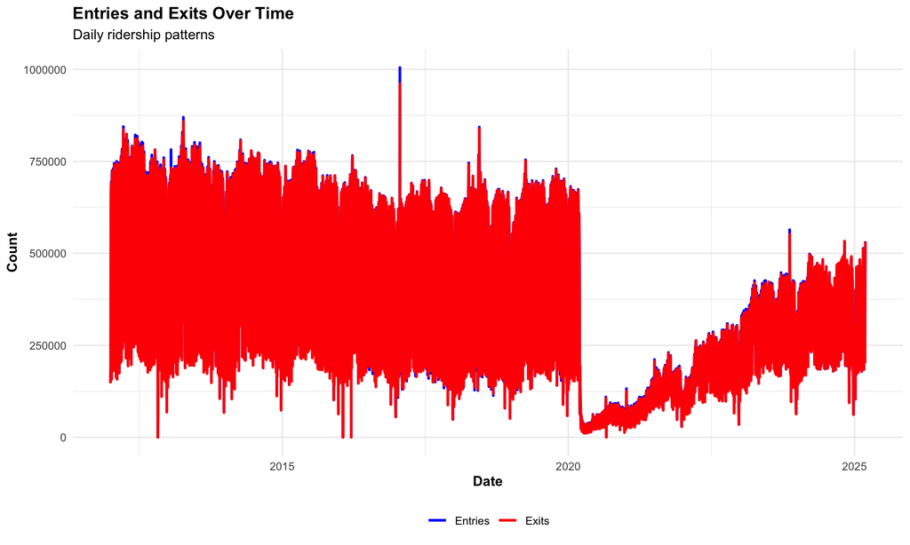

Daily entries and exits over time

```r
# Check if Date column exists and has valid data
if("Date" %in% names(total_entries_exits) &&
   is.numeric(total_entries_exits$Entries) &&
   is.numeric(total_entries_exits$Exits)) {

  # Convert to Date type if it's not already
  if(!inherits(total_entries_exits$Date, "Date")) {
    total_entries_exits$Date <- as.Date(total_entries_exits$Date)
  }

  # Create time series plot of entries and exits
  ggplot(total_entries_exits, aes(x = Date)) +
    geom_line(aes(y = Entries, color = "Entries"), size = 1) +
    geom_line(aes(y = Exits, color = "Exits"), size = 1) +
    labs(
      title = "Entries and Exits Over Time",
      subtitle = "Daily ridership patterns",
      x = "Date",
      y = "Count"
    ) +
    scale_color_manual(values = c("Entries" = "blue", "Exits" = "red")) +
    theme_minimal() +
    theme(
      legend.title = element_blank(),
      legend.position = "bottom",
      plot.title = element_text(face = "bold"),
      axis.title = element_text(face = "bold")
    )
} else {
  cat("Cannot create time trends plot - missing Date column or invalid data\n")
}
```

### 📅 Day of Week Patterns

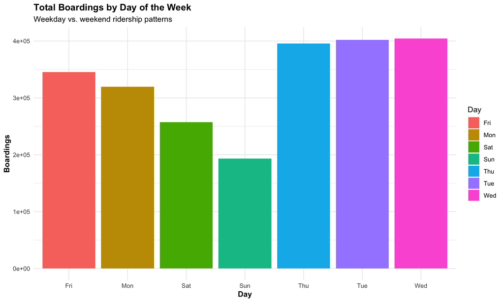

Ridership distribution by day of week

```r
# Using the correct column name for boardings
if("Day" %in% names(boardings_by_day) && "Boardings" %in% names(boardings_by_day)) {
  ggplot(boardings_by_day, aes(x = Day, y = Boardings, fill = Day)) +
    geom_bar(stat = "identity") +
    labs(
      title = "Total Boardings by Day of the Week",
      subtitle = "Weekday vs. weekend ridership patterns",
      x = "Day",
      y = "Boardings"
    ) +
    theme_minimal() +
    theme(
      plot.title = element_text(face = "bold"),
      axis.title = element_text(face = "bold")
    )
} else {
  # Create a simplified version using original column names
  ggplot(boardings_by_day, aes(x = boardings_by_day[[1]], y = boardings_by_day[[2]])) +
    geom_bar(stat = "identity", fill = "steelblue") +
    labs(
      title = "Total Boardings by Day of the Week",
      x = names(boardings_by_day)[1],
      y = names(boardings_by_day)[2]
    ) +
    theme_minimal() +
    theme(
      plot.title = element_text(face = "bold"),
      axis.title = element_text(face = "bold")
    )
}
```

### 📅 Monthly Ridership Patterns

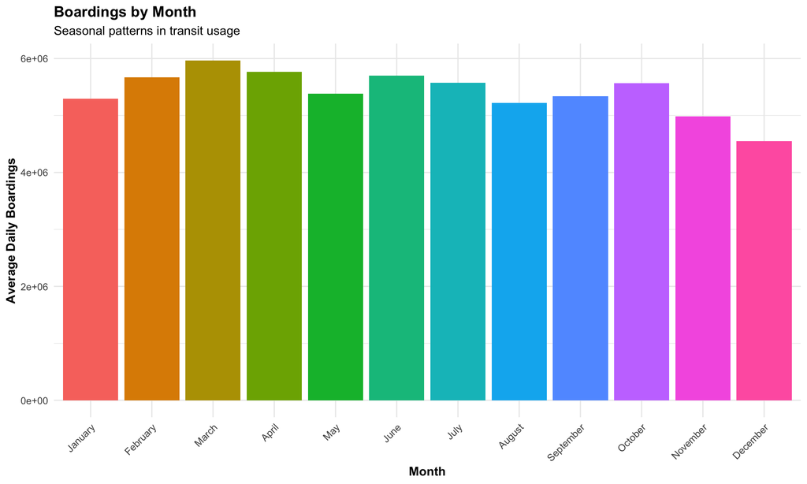

Monthly ridership distribution

```r
boardings_data <- read_csv("Cleaned_Boardings_Data.csv")

# Aggregate data by month (sum of avg_daily across years and tap types)
boardings_by_month <- boardings_data %>%
  group_by(month) %>%
  summarize(Value = sum(avg_daily, na.rm = TRUE)) %>%
  rename(Month = month)

# Ensure proper month ordering
month_order <- c("January", "February", "March", "April", "May", "June",
                "July", "August", "September", "October", "November", "December")
boardings_by_month$Month <- factor(boardings_by_month$Month, levels = month_order)

# Create the plot
ggplot(boardings_by_month, aes(x = Month, y = Value, fill = Month)) +
  geom_bar(stat = "identity") +
  labs(
    title = "Boardings by Month",
    subtitle = "Seasonal patterns in transit usage",
    x = "Month",
    y = "Average Daily Boardings"
  ) +
  theme_minimal() +
  theme(
    axis.text.x = element_text(angle = 45, hjust = 1),
    plot.title = element_text(face = "bold"),
    axis.title = element_text(face = "bold"),
    legend.position = "none"
  )
```

## 🚉 Station-Level Analysis

### 🥇 Top Stations by Ridership

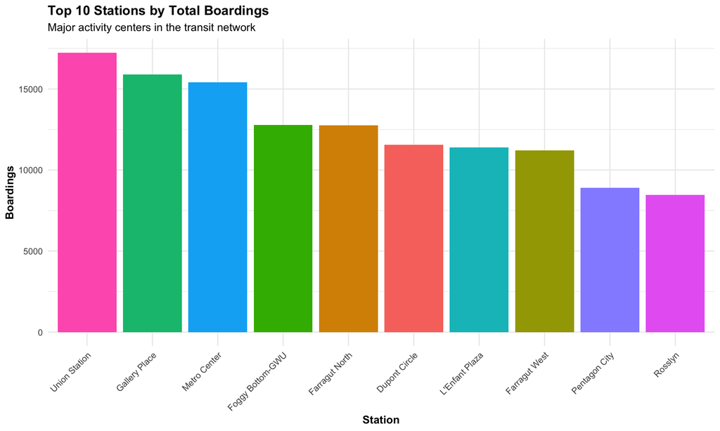

Top 10 stations by total boardings

```r
# Check if the file has the expected structure based on our inspection
if("Station Name" %in% names(boardings_by_route)) {
  # Create a new column with total boardings across all time periods
  boardings_by_route <- boardings_by_route %>%
    mutate(Total = `AM Peak (Open-9:30am)` +
           `Midday (9:30am-3pm)` +
           `PM Peak (3pm-7pm)` +
           `Evening (7pm-12am)` +
           `Late Night (12am-Close)`)

  # Get top stations
  top_stations <- boardings_by_route %>%
    arrange(desc(Total)) %>%
    slice_head(n = 10)

  # Create the plot
  ggplot(top_stations, aes(x = reorder(`Station Name`, -Total), y = Total, fill = `Station Name`)) +
    geom_bar(stat = "identity") +
    labs(
      title = "Top 10 Stations by Total Boardings",
      subtitle = "Major activity centers in the transit network",
      x = "Station",
      y = "Boardings"
    ) +
    theme_minimal() +
    theme(
      axis.text.x = element_text(angle = 45, hjust = 1),
      legend.position = "none",
      plot.title = element_text(face = "bold"),
      axis.title = element_text(face = "bold")
    )
} else {
  cat("Cannot create station boardings plot - required columns not found\n")
}
```

### ⏰ Time Period Distribution Analysis

```r
if("Station Name" %in% names(boardings_by_route)) {
  # Calculate system-wide percentages by time period
  total_by_time <- colSums(boardings_by_route[, 2:6], na.rm = TRUE)
  total_all_periods <- sum(total_by_time)

  time_period_pct <- data.frame(
    TimePeriod = names(total_by_time),
    Boardings = total_by_time,
    Percentage = round(100 * total_by_time / total_all_periods, 1)
  )

  # Create a bar chart of distribution by time period
  ggplot(time_period_pct, aes(x = reorder(TimePeriod, -Percentage), y = Percentage, fill = TimePeriod)) +
    geom_bar(stat = "identity") +
    labs(
      title = "Distribution of Boardings by Time Period",
      subtitle = "Peak vs. off-peak travel patterns",
      x = "Time Period",
      y = "Percentage of Total Boardings"
    ) +
    theme_minimal() +
    theme(
      axis.text.x = element_text(angle = 45, hjust = 1),
      legend.position = "none",
      plot.title = element_text(face = "bold"),
      axis.title = element_text(face = "bold")
    )

  # Print the table
  cat("System-wide distribution of boardings by time period:\n")
  print(time_period_pct)
}
```

```
## System-wide distribution of boardings by time period:
##                                      TimePeriod Boardings Percentage
## AM Peak (Open-9:30am)     AM Peak (Open-9:30am)    117268       28.7
## Midday (9:30am-3pm)         Midday (9:30am-3pm)     93155       22.8
## PM Peak (3pm-7pm)             PM Peak (3pm-7pm)    145441       35.6
## Evening (7pm-12am)           Evening (7pm-12am)     51305       12.5
## Late Night (12am-Close) Late Night (12am-Close)      1781        0.4
```

## 📊 Statistical Analysis

### 📉 ANOVA: Analyzing Day of Week Variations

```r
# First check if we have the required columns and enough data points for ANOVA
if("Boardings" %in% names(boardings_by_day) && "Day" %in% names(boardings_by_day)) {
  if(nrow(boardings_by_day) >= 7) {  # Need at least one data point per day
    tryCatch({
      # Perform one-way ANOVA to test if day of week affects ridership
      anova_boardings <- aov(Boardings ~ Day, data = boardings_by_day)
      summary_result <- summary(anova_boardings)

      # Display ANOVA results
      cat("One-way ANOVA: Testing if boardings differ by day of week\n")
      print(summary_result)

      # Perform post-hoc test if ANOVA is significant
      if(length(summary_result) > 0 &&
         is.list(summary_result[[1]]) &&
         "Pr(>F)" %in% names(summary_result[[1]])) {

        if(summary_result[[1]]$`Pr(>F)`[1] < 0.05) {
          cat("\nANOVA shows significant differences. Performing Tukey's HSD post-hoc test:\n")
          posthoc <- TukeyHSD(anova_boardings)
          print(posthoc)

          # Visualize post-hoc test results
          cat("\nVisualization of pairwise comparisons:\n")
          plot(posthoc, las = 1)
        } else {
          cat("No significant differences in boardings between days (p >=0.05)\n")
        }
      } else {
        cat("ANOVA results structure differs from expected - check data\n")
      }
    }, error = function(e) {
      cat("Error in ANOVA test:", conditionMessage(e), "\n")
      cat("This could be due to insufficient variation in the data\n")
    })
  } else {
    cat("Insufficient data for ANOVA - need at least one data point per day\n")
  }
} else {
  cat("Required columns 'Boardings' and/or 'Day' not found in boardings_by_day\n")
}
```

```
## One-way ANOVA: Testing if boardings differ by day of week
##             Df    Sum Sq   Mean Sq
## Day          6 3.936e+10 6.559e+09
## ANOVA results structure differs from expected - check data
```

## 💡 Key Insights and Findings

```r
cat("=== TRANSIT SYSTEM KEY FINDINGS ===\n\n")
```

```
## === TRANSIT SYSTEM KEY FINDINGS ===
```

```r
# System-level metrics
if("Entries" %in% names(total_entries_exits) && "Exits" %in% names(total_entries_exits)) {
  total_avg_entries <- mean(total_entries_exits$Entries, na.rm = TRUE)
  total_avg_exits <- mean(total_entries_exits$Exits, na.rm = TRUE)

  cat("SYSTEM UTILIZATION:\n")
  cat("• Average daily entries:", formatC(round(total_avg_entries), format="f", big.mark=",", digits=0), "\n")
  cat("• Average daily exits:", formatC(round(total_avg_exits), format="f", big.mark=",", digits=0), "\n")

  # Calculate ratio of entries to exits
  ratio <- mean(total_entries_exits$Entries, na.rm = TRUE) /
           mean(total_entries_exits$Exits, na.rm = TRUE)
  cat("• Entry/exit ratio:", round(ratio, 2), "\n")
}
```

```
## SYSTEM UTILIZATION:
## • Average daily entries: 408,941
## • Average daily exits: 406,412
## • Entry/exit ratio: 1.01
```

```r
# Daily patterns
if("Boardings" %in% names(boardings_by_day) && "Day" %in% names(boardings_by_day)) {
  busiest_day <- boardings_by_day %>%
    arrange(desc(Boardings)) %>%
    slice(1) %>%
    pull(Day)

  lightest_day <- boardings_by_day %>%
    arrange(Boardings) %>%
    slice(1) %>%
    pull(Day)

  cat("\nTEMPORAL PATTERNS:\n")
  cat("• Busiest day of week:", busiest_day, "\n")
  cat("• Lightest day of week:", lightest_day, "\n")
} else if(length(names(boardings_by_day)) >= 2) {
  # Use original column names if we couldn't rename
  busiest_day <- boardings_by_day %>%
    arrange(desc(.[[2]])) %>%
    slice(1) %>%
    pull(1)

  cat("• Busiest day of week:", busiest_day, "\n")
}
```

```
##
## TEMPORAL PATTERNS:
## • Busiest day of week: Wed
## • Lightest day of week: Sun
```

```r
# Station insights
if("Station Name" %in% names(boardings_by_route)) {
  # Top station by total boardings
  if("Total" %in% names(boardings_by_route)) {
    top_station <- boardings_by_route %>%
      arrange(desc(Total)) %>%
      slice(1)

    cat("\nSTATION UTILIZATION:\n")
    cat("• Busiest station:", top_station$`Station Name`,
        "with", formatC(top_station$Total, format="f", big.mark=",", digits=0), "daily boardings\n")
  }

  # AM vs PM peak patterns
  am_peak_sum <- sum(boardings_by_route$`AM Peak (Open-9:30am)`, na.rm = TRUE)
  pm_peak_sum <- sum(boardings_by_route$`PM Peak (3pm-7pm)`, na.rm = TRUE)

  cat("• AM Peak total boardings:", formatC(am_peak_sum, format="f", big.mark=",", digits=0), "\n")
  cat("• PM Peak total boardings:", formatC(pm_peak_sum, format="f", big.mark=",", digits=0), "\n")
  cat("• PM to AM ratio:", round(pm_peak_sum/am_peak_sum, 2), "\n")
}
```

```
##
## STATION UTILIZATION:
## • Busiest station: Union Station with 17,235 daily boardings
## • AM Peak total boardings: 117,268
## • PM Peak total boardings: 145,441
## • PM to AM ratio: 1.24
```

```r
# Fare technology adoption
if(all(c("Avg Daily Tapped Entries", "Avg Daily NonTapped Entries") %in% names(entries_by_tap))) {
  total_tapped <- sum(entries_by_tap$`Avg Daily Tapped Entries`, na.rm = TRUE)
  total_non_tapped <- sum(entries_by_tap$`Avg Daily NonTapped Entries`, na.rm = TRUE)
  total_entries <- total_tapped + total_non_tapped

  cat("\nFARE TECHNOLOGY ADOPTION:\n")
  cat("• Tap entry usage rate:",
      round(100 * total_tapped / total_entries, 1), "%\n", sep = "")
  cat("• Non-tap entry usage rate:",
      round(100 * total_non_tapped / total_entries, 1), "%\n", sep = "")
}
```

```
##
## FARE TECHNOLOGY ADOPTION:
## • Tap entry usage rate:92.2%
## • Non-tap entry usage rate:7.8%
```